# Project: Statistical Segmentation of Resellers vs. Normal Users

## 1. Problem Statement

Our platform has a diverse user base ranging from casual individual buyers to high-volume commercial resellers. However, we currently lack a rigorous, data-driven method to distinguish between these two groups.

Simple "average" metrics fail because the data is highly skewed a small number of power users distort the mean. Without a clear separation, we cannot:

- Tailor support (e.g., VIP lanes for resellers).
- Detect policy abuse.
- Accurately forecast revenue risks.

**The Goal:** To identify a statistically robust threshold for `DAY_AVG_NMV` (Daily Average Net Merchandise Value) that separates "Normal Users" from "Resellers" using unsupervised anomaly detection techniques.

## 2. Methodology & Key Assumptions

To solve this, we use the **Box-Cox Transformation**, a statistical technique designed to normalize highly skewed data.

**Key Assumptions:**

1. **NMV as a Proxy:** We assume `DAY_AVG_NMV` is the strongest signal for reseller intent. While purchase frequency matters, daily volume is the primary differentiator for commercial activity.
2. **Lognormal-like Distribution:** User spending data typically follows a "power law" or lognormal distribution (many small spenders, few whales). We assume that by transforming this data into a normal (bell curve) shape, we can use Standard Deviations (SD) to identify outliers.
3. **The "1.5 Sigma" Rule:** We define a "Reseller" as anyone falling more than **1.5 Standard Deviations** above the mean in the transformed space. This is a conservative threshold designed to isolate the statistically significant "tail" of the distribution.
4. **Positive Data Constraint:** Box-Cox requires strictly positive data. We assume that adding a negligible shift ($+0.0001$) to handle zeros does not distort the behavior of high-value users.

## 3. Scope & Limitations (The "What Not")

It is important to define what this analysis is **not** doing:

- **Not a Classification Model:** This is an unsupervised segmentation. We are not training a model on "known" resellers (labeled data); we are discovering them based on statistical divergence.
- **Static Snapshot:** The threshold is calculated based on the current dataset's distribution. If the business grows significantly, this threshold should be recalculated.

#### Imports & Configuration

```python
import pandas as pd
import numpy as np
from scipy import stats
import matplotlib.pyplot as plt
import seaborn as sns

# Set plot style
sns.set(style="whitegrid")
plt.rcParams['figure.figsize'] = (12, 6)

# Display options to avoid scientific notation
pd.set_option('display.float_format', lambda x: '%.2f' % x)
```

#### Data Loading & Preprocessing

```python
# 1. Load Data
df = pd.read_excel('Reseller Split.xlsx')

# We add a tiny constant (shift) to handle zeros without distorting the high-value data
shift_value = 0.0001
df['NMV_Shifted'] = df['DAY_AVG_NMV'] + shift_value

print(f"Data Loaded: {df.shape[0]} rows")
print("--- Descriptive Statistics ---")
print(df[['DAY_AVG_NMV', 'TOTAL_NMV']].describe())
```

```
Data Loaded: 85099 rows
--- Descriptive Statistics ---
       DAY_AVG_NMV  TOTAL_NMV
count     85099.00   85099.00
mean         71.45     472.42
std         544.51   17650.39
min           0.00       0.00
25%           1.00       1.35
50%           3.18       6.69
75%          14.72      35.62
max       32936.62 2033129.79
```

#### Box-Cox Transformation & Threshold Calculation

```python
# 1. Apply Box-Cox Transformation
data_transformed, best_lambda = stats.boxcox(df['NMV_Shifted'])
mean_trans = np.mean(data_transformed)
std_trans = np.std(data_transformed)
```

```python
# 2. Helper Function: Inverse Box-Cox
def inv_boxcox(y, ld, shift):
    if ld == 0: return np.exp(y) - shift
    else: return (y * ld + 1)**(1/ld) - shift
```

```python
# 3. Calculate All Potential Thresholds for the Table
sd_multipliers = [1, 1.5, 2, 3]
comparison_data = []

for mult in sd_multipliers:
    limit_trans = mean_trans + (mult * std_trans)
    limit_orig = inv_boxcox(limit_trans, best_lambda, shift_value)

    comparison_data.append({
        'SD Cut-off': f'{mult} SD',
        'Threshold ($ NMV)': limit_orig,
        'Resellers (#)': len(df[df['DAY_AVG_NMV'] > limit_orig]),
        'Resellers (%)': (len(df[df['DAY_AVG_NMV'] > limit_orig]) / len(df)) * 100,
        'Revenue Captured (%)': (df[df['DAY_AVG_NMV'] > limit_orig]['TOTAL_NMV'].sum() / df['TOTAL_NMV'].sum()) * 100
    })

logic_df = pd.DataFrame(comparison_data)
print("--- Threshold Logic Justification ---")
print(logic_df)
```

```
--- Threshold Logic Justification ---
  SD Cut-off  Threshold ($ NMV)  Resellers (#)  Resellers (%)  \
0       1 SD              27.09          13727          16.13
1     1.5 SD              98.42           5622           6.61
2       2 SD             467.59           2339           2.75
3       3 SD           48479.55              0           0.00

   Revenue Captured (%)
0                 96.07
1                 92.12
2                 86.28
3                  0.00
```

```python
chosen_threshold_trans = mean_trans + (1.5 * std_trans)
chosen_threshold = inv_boxcox(chosen_threshold_trans, best_lambda, shift_value)

print(f"\nCONCLUSION: We choose 1.5 SD.")
print(f"Chosen Threshold Value: {chosen_threshold:.2f}")
```

```
CONCLUSION: We choose 1.5 SD.
Chosen Threshold Value: 98.42
```

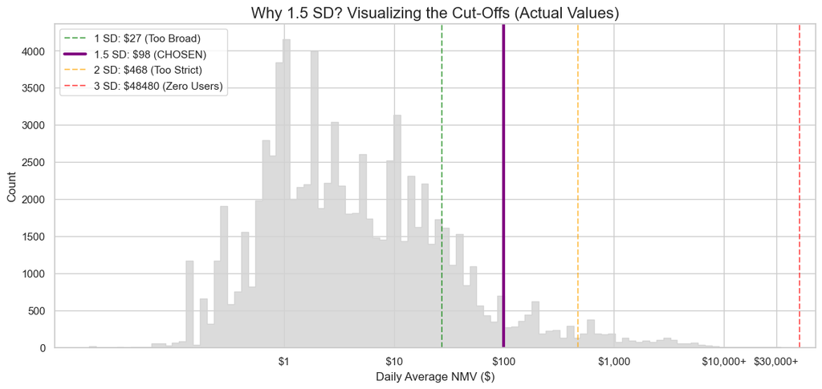

```python
# --- VISUALIZATION: Histogram with "Actual Values" X-Axis ---
plt.figure(figsize=(14, 6))

# Filter for log plot stability
plot_data = df[df['DAY_AVG_NMV'] > 0]

# Plot Distribution
sns.histplot(plot_data['DAY_AVG_NMV'], bins=100, log_scale=True, element="step", color='lightgrey', alpha=0.8)

# Plot the Candidate Lines (using calculated variables)
# Ensure you have run the calculation cell before this!
# t1, t1_5, t2, t3 variables come from Cell 4 logic
plt.axvline(t1, color='green', linestyle='--', alpha=0.6, label=f'1 SD: ${t1:.0f} (Too Broad)')
plt.axvline(t1_5, color='purple', linestyle='-', linewidth=3, label=f'1.5 SD: ${t1_5:.0f} (CHOSEN)')
plt.axvline(t2, color='orange', linestyle='--', alpha=0.6, label=f'2 SD: ${t2:.0f} (Too Strict)')
plt.axvline(t3, color='red', linestyle='--', alpha=0.6, label=f'3 SD: ${t3:.0f} (Zero Users)')

# --- CUSTOM FORMATTING ---
# Force the X-axis to show readable "Actual Values"
custom_ticks = [1, 10, 100, 1000, 10000, 30000]
custom_labels = ['$1', '$10', '$100', '$1,000', '$10,000+', '$30,000+']
plt.xticks(custom_ticks, custom_labels)

plt.title('Why 1.5 SD? Visualizing the Cut-Offs (Actual Values)', fontsize=16)
plt.xlabel('Daily Average NMV ($)', fontsize=12)
plt.legend()

plt.show()
```

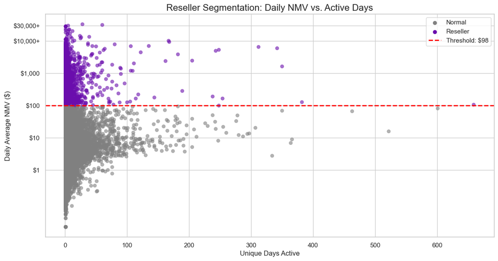

```python
# --- VISUALIZATION: Scatter Plot with "Actual Values" Axis ---
plt.figure(figsize=(14, 7))

# Filter out zeros for log plot stability
plot_data = df[df['DAY_AVG_NMV'] > 0]

# Create Scatter Plot
sns.scatterplot(data=plot_data, x='UNIQUE_DAYS', y='DAY_AVG_NMV',
                hue='Segment', hue_order=['Normal', 'Reseller'],
                palette={'Normal': 'grey', 'Reseller': '#6a0dad'},
                alpha=0.6, edgecolor=None)

# Add Threshold Line
plt.axhline(chosen_threshold, color='red', linestyle='--', linewidth=2, label=f'Threshold: ${chosen_threshold:.0f}')

# Set Log Scale for the visual spread
plt.yscale('log')

# --- CUSTOM FORMATTING ---
# Force the Y-axis to show readable "Actual Values"
custom_ticks = [1, 10, 100, 1000, 10000, 30000]
custom_labels = ['$1', '$10', '$100', '$1,000', '$10,000+', '$30,000+']
plt.yticks(custom_ticks, custom_labels)

plt.title('Reseller Segmentation: Daily NMV vs. Active Days', fontsize=16)
plt.xlabel('Unique Days Active', fontsize=12)
plt.ylabel('Daily Average NMV ($)', fontsize=12)
plt.legend(loc='upper right')

plt.show()
```

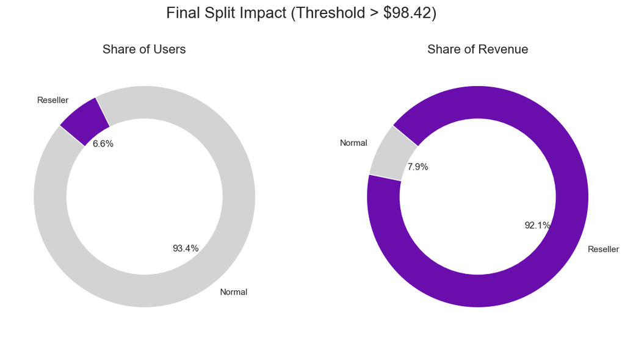

```
Final Segmentation:
    Segment  User_Count  Total_Revenue
0    Normal       79477     3168215.40
1  Reseller        5622    37034189.78
```

```python
# Apply the chosen segment
df['Segment'] = np.where(df['DAY_AVG_NMV'] > chosen_threshold, 'Reseller', 'Normal')

# Aggregate
summary = df.groupby('Segment').agg(
    User_Count=('DAY_AVG_NMV', 'count'),
    Total_Revenue=('TOTAL_NMV', 'sum')
).reset_index()

# Visualization: The Impact Pie Charts
fig, axes = plt.subplots(1, 2, figsize=(14, 7))
colors = {'Normal': 'lightgrey', 'Reseller': '#6a0dad'} # Purple
color_list = [colors[x] for x in summary['Segment']]

# Users Pie
axes[0].pie(summary['User_Count'], labels=summary['Segment'], autopct='%1.1f%%', startangle=140, colors=color_list)
axes[0].set_title('Share of Users', fontsize=16)
axes[0].add_artist(plt.Circle((0,0),0.70,fc='white'))

# Revenue Pie
axes[1].pie(summary['Total_Revenue'], labels=summary['Segment'], autopct='%1.1f%%', startangle=140, colors=color_list)
axes[1].set_title('Share of Revenue', fontsize=16)
axes[1].add_artist(plt.Circle((0,0),0.70,fc='white'))

plt.suptitle(f'Final Split Impact (Threshold > ${chosen_threshold:.2f})', fontsize=20)
plt.show()

print("Final Segmentation:")
print(summary)
```